# HW2_Sterpa

Marco Aurelio Sterpa

26/12/2020

```r
library(mixtools)
library(caret)
library(KScorrect)
library(gt)
library(plyr)

# helper functions used to compute the vectorized (log)likelihood
vnorm <- function(y, p, mu, sigma) p * dnorm(y, mu, sigma)
vect_wnorm <- Vectorize(vnorm, c("p", "mu", "sigma"))
log_vnorm <- function(y, p, mu, sigma) p * dnorm(y, mu, sigma, log = TRUE)
vect_log_wnorm <- Vectorize(vnorm, c("p", "mu", "sigma"))
vect_norm = Vectorize(dnorm, c("mean", "sd"))
```

In order to study the performance of different model selection methods on the EM-fit of the Bart Simpson distribution we will first need a procedure to create a sample from this density.

```r
# create a random sample
sample_sim <- function(n) rnormmix(n,
                                   lambda = c(0.5, rep(0.1,5)),
                                   mu     = c(0, ((0:4)/2)-1),
                                   sigma  = c(1, rep(0.1,5)))
```

We will use two sample of size 100 and 1000 showing respectively a non-asymptotic and asymptotic behaviour. Here’s a clearly non asymptotic sample:

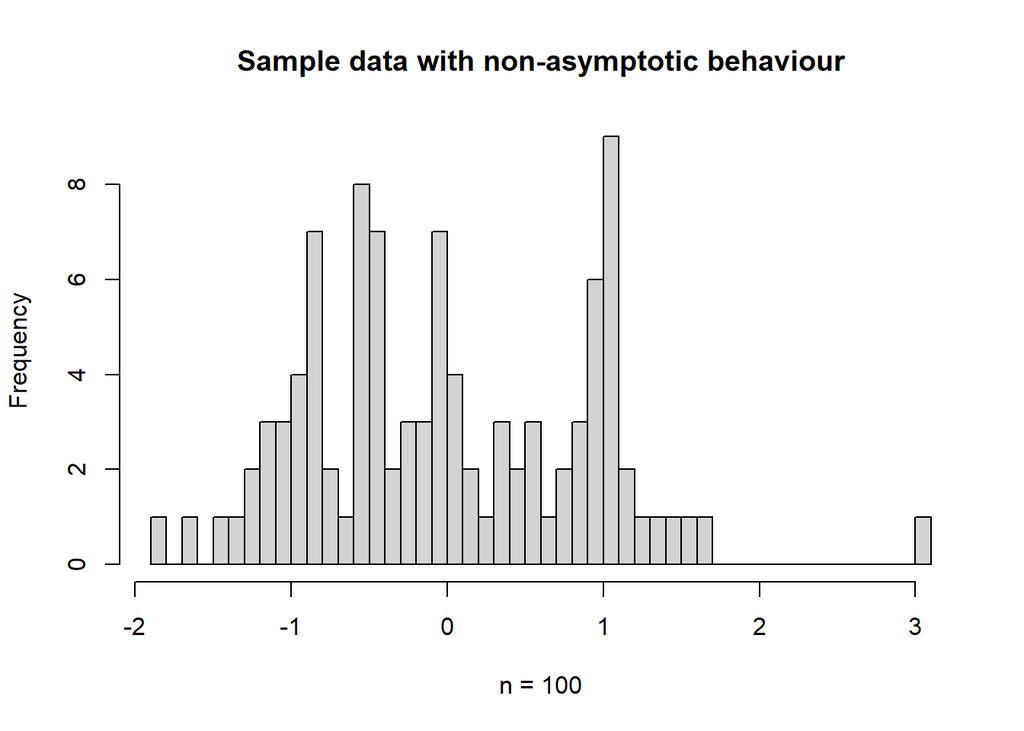

```r
small_sample <- sample_sim(100)
hist(small_sample,
     main = "Sample data with non-asymptotic behaviour",
     xlab = "n = 100",
     breaks = 50)
```

And here’s a sample that clearly looks more much more like the Bart:

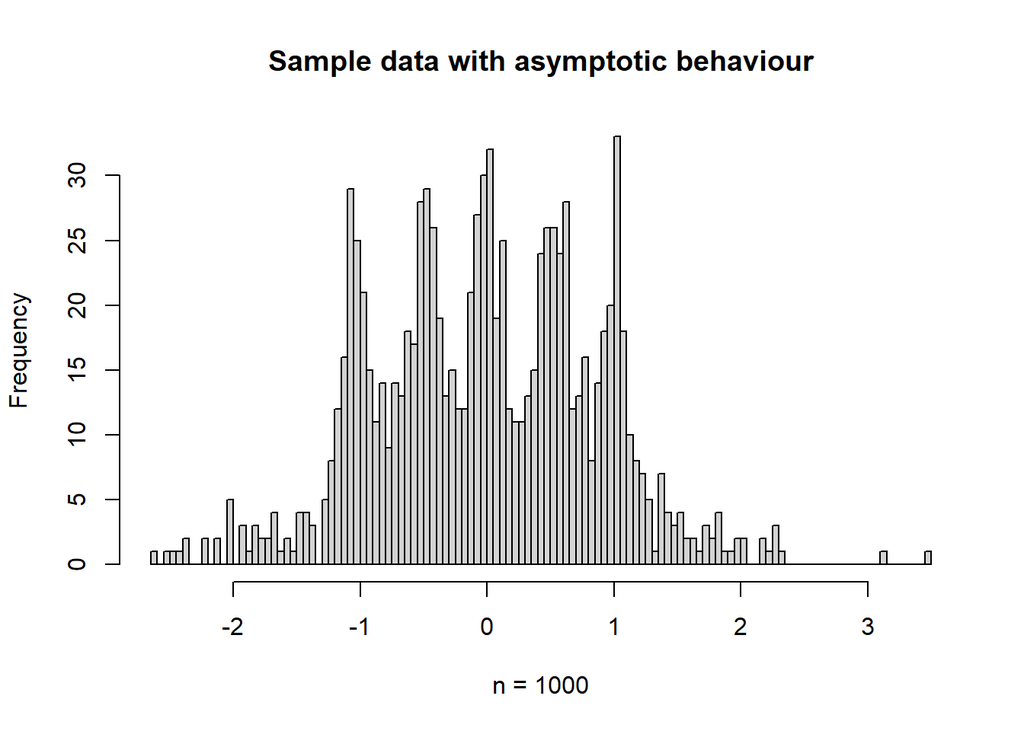

```r
large_sample <- sample_sim(1000)
hist(large_sample,
     main = "Sample data with asymptotic behaviour",
     xlab = "n = 1000",
     breaks = 100)
```

We start by defining an EM-fit procedure for a mixture of a generic number of components and a simple function to compute the loglikelihood given the output of the EM-fit.

```r
# Handmade EM4MoG ---------------------------------------------------------
handmade.em <- function(y, p, mu, sigma, breaks = 50, n_iter = 1000,
                        threshold = 1e-3, plot = F, plot_freq = 25)
{
  # vectorized likelihood
  like     <- apply(vect_wnorm(y, p, mu, sigma), 1, sum)
  deviance <- -2 * sum(log(like))
  k <- length(p)

  # creating matrix of iteration values
  n_col    <- 2 + 3 * k
  res      <- matrix(NA, n_iter + 1, n_col)
  res[1,]  <- c(0, p, mu, sigma, deviance)

  for (iter in 1:n_iter) {
    # E step
    d   <- vect_wnorm(y, p, mu, sigma) # matrix of responsabilities
    den <- apply(d, 1, sum) # normalizing factor
    r <- d / den # normalizing each column
    r[is.na(r)] = 1

    # M step
    p <- apply(r, 2, mean)
    mu <- apply(r, 2, function(x) sum(x * y) / sum(x))
    #for (i in 1:k) {
    #  mu[i] <- sum(r[,i] * y) / sum(r[,i])
    #}

    for (i in 1:k) sigma[i] <- sqrt(sum(r[,i] * (y - mu[i])^2) / sum(r[,i]))
    #sigma <- apply(1:k, 2, function(i) sqrt(sum(r[,i] * (y - mu[i])^2) / sum(r[,i]) ) )
    #sigma <- sqrt(sigma - mu^2)

    # -2 x log-likelihood (a.k.a. deviance)
    new_like <- log(apply(vect_wnorm(y, p, mu, sigma), 1, sum))

    # stopping criteria
    diff <- abs(sum(like) - sum(new_like))
    if (!is.na(diff) && diff < threshold) break
    like     <- new_like
    deviance <- -2 * sum(like)

    # Save
    res[iter+1,] <- c(iter, p, mu, sigma, deviance)

    # Plot
    if (plot && iter %% plot_freq == 0) {
      xlab <- paste("EM Iteration: ", iter, "/", n_iter, sep = "")
      plot_fit(y, p, mu, sigma, xlab)
      Sys.sleep(1)
    }
  }
  res <- data.frame(res)

  # function to generate strings
  append_str <- function(str) sapply(1:k, function(x) paste(str, x, sep=''))
  p_names <- append_str("p")
  mu_names <- append_str("mu")
  sigma_names <- append_str("sigma")
  names(res) <- c("iteration", p_names, mu_names, sigma_names, "deviance")
  out <- list(p = p, mu = mu, sigma = sigma, deviance = deviance, res = res, iter = iter)
  return(out)
}

log_likelihood <- function(x, hm.fit) {
  # x : vector
  # hm.fit : output of handmade.em function
  like <- apply(vect_wnorm(x, hm.fit$p, hm.fit$mu, hm.fit$sigma), 1, sum)
  log_like <- sum(log(like))
  return(log_like)
}
```

```r
init_kmeans <- function(y, k) {
  # takes the data and the number of components and returns
  # initial parameters (proportions, mean, std) running the
  # kmeans algotithm
  labels <- kmeans(y, k)$cluster
  mu <- unlist(lapply(1:k, function(i) mean(y[labels == i])))
  sigma <- unlist(lapply(1:k, function(i) sd(y[labels == i])))
  p <- unlist(lapply(1:k, function(i) sum(labels == i) / length(labels)))
  return(list(p = p, mu = mu, sigma = sigma))
}

init_params <- function(k) {
  # takes the data and the number of components and returns random
  # initial parameters, data are used to compute min/max to
  # generate mu and sigma
  p <- runif(k, 0, 1)
  p <- p / sum(p)
  mu <- runif(k, 0, 1)
  sigma <- runif(k, 0, 1)
  return(list(p = p, mu = mu, sigma = sigma))
}

init_params_groups <- function(y, k) {
  # takes the data and the number of components and returns random
  # initial parameters, data are used to compute min/max to
  # generate mu and sigma
  folds <- createFolds(y, k) # group of indexes
  folds <- rapply(folds, function(x) y[x], how = "replace") # groups of values
  p <- rep(1 / k, k) # same proportion for each component
  p <- p / sum(p) # normalizing
  mu <- as.vector(rapply(folds, mean)) # mean of each random group
  sigma <- as.vector(rapply(folds, sd))
  return(list(p = p, mu = mu, sigma = sigma))
}
```

Some of the model selection methods that will used include sample splitting and cross validation, the following functions are helpful in making the simulation code a little more neat.

```r
sample_split <- function(x, ratio) {
  # x : data
  # ratio : float (represents length(train)/)
  # returns a random split of x in train and test set based on ratio
  n <- length(x)
  n_train <- as.integer(n * ratio)
  train_idx <- sample(1:n, size = n_train) # sample indexes for trainset
  test_idx <- setdiff(1:n, train_idx)
  return(list(train = x[train_idx], test = x[test_idx]))
}

kfold_to_split <- function(XX, kfold, k) {
  # kfold : is the result of createFolds() with names Fold1, Fold2, ...
  # returns a list with names train and test, setting Fold_k as test set
  # and the rest as training set
  train_fold_idxs <- setdiff(1:length(kfold), k)
  train_idxs <- unlist(kfold[train_fold_idxs], use.names = F)
  test_idxs <- kfold[[k]]
  return(list(train = XX[train_idxs], test = XX[test_idxs]))
}

kfold_cv <- function(XX, n_fold, k) {
  # x : data
  # k : number of folds
  # returns the average risk running a kfold cross validation on x
  kfold <- createFolds(XX, n_fold) # named list of Fold1, Fold2, ...
  outs <- rep(NA, n_fold)

  for (i in 1:n_fold) {
    x_split <- kfold_to_split(XX, kfold, i) # named list of train/test
    params <- init_kmeans(x_split$train, k)
    hm.fit <- handmade.em(x_split$train, params$p, params$mu, params$sigma)
    outs[i] <- log_likelihood(x_split$test, hm.fit) / length(x_split$test)
  }
  return(mean(outs[!is.nan(outs)]))
}
```

Finally here’s the simulation function that takes the sample size, the number of simulations to run and $k_{max}$ and runs M simulation for each $k \in \{1, \dots, k_{max}\}$ saving the performance of each model selection method on the result of the EM-fit.

```r
EM_simulation <- function(n, M, k_max, subdivisions = 200) {
  # n : sample size
  # M : number of simulations
  # k_max : maximum number of components
  # n_iter : number of iterations of EM

  result <- matrix(nrow = 8, ncol = M)
  model_performance <- array(dim = c(8, k_max, M))

  for (n_sim in 1:M) {

    # sample from Bart
    XX <- sample_sim(n)

    # model evaluation matrix
    model_eval <- matrix(nrow = 8, ncol = k_max)

    for (k in 1:k_max) {
      # first run EM algorithm on the whole dataset to compute AIC and BIC
      params <- init_kmeans(XX, k) # initial random parameters
      hm.fit <- handmade.em(XX, params$p, params$mu, params$sigma)

      # AIC and BIC evaluation
      log_like <- log_likelihood(XX, hm.fit)
      model_eval[1,k] <- 2 * log_like - 2 * k * 3
      model_eval[2,k] <- 2 * log_like - log(n) * k * 3

      # cross validation on different split ratios
      ratios = c(.5, .7, .3)

      for (i in 1:3) {
        x_split <- sample_split(XX, ratios[i])
        params <- init_kmeans(x_split$train, k) # initial parameters
        hm.fit <- handmade.em(x_split$train, params$p, params$mu, params$sigma)
        log_like <- log_likelihood(x_split$test, hm.fit) / length(x_split$test)
        model_eval[i+2,k] <- log_like
      }

      # 5-fold cross validation
      model_eval[6,k] <- kfold_cv(XX, 5, k)

      # 10-fold cross validation
      model_eval[7,k] <- kfold_cv(XX, 10, k)

      # Wasserstein score
      x_split <- sample_split(XX, .5) # split data in half
      params <- init_kmeans(x_split$train, k)
      hm.fit <- handmade.em(x_split$train, params$p, params$mu, params$sigma) # get MLE from trainset
      f_k <- function(p) qmixnorm(p, mean = hm.fit$mu,
                                  sd = hm.fit$sigma,
                                  pro = hm.fit$p,
                                  expand = .2) # quantile function on the MLE
      test_ecdf <- ecdf(x_split$test) # ecdf of the test set
      f_test <- function(p) as.numeric(quantile(test_ecdf, probs = p)) # quantile function of testset ecdf
      f_abs <- function(p) abs(f_k(p) - f_test(p)) # integrand
      model_eval[8,k] <- integrate(f_abs, lower = 0, upper = 1,
                                   subdivisions = subdivisions,
                                   stop.on.error = FALSE)$value
    }

    # take best k for each mode evaluation and save it in the result matrix
    model_eval[is.nan(model_eval)] = -Inf # eliminating possible NaN values
    model_performance[,,n_sim] = model_eval
    result[,n_sim] <- tryCatch(unlist(apply(model_eval, 1, which.max)))  # select the best k for each simulation
  }

  return(list("best_k" = result, "performance" = model_performance))
}
```

```r
n_1 <- 100
n_2 <- 1000
M <- 100
k_max <- 8
small.result <- EM_simulation(n_1, M, k_max)
large.result <- EM_simulation(n_2, M, k_max)
```

We can now look at the accuracy of each model in predicting the real value $k^*=6$.

```r
accuracy <- function(k_matrix, k) {
  result <- unlist(apply(k_matrix, 1, function(x) sum(x == k) / length(x)))
  return(result)
}

make.accuracy.table <- function(k_matrix, k_max) {
  accuracy.table <- ldply(1:k_max, function(i) accuracy(k_matrix, i))
  colnames(accuracy.table) <- model.names
  k <- 1:k_max
  return(cbind(k, accuracy.table))
}

# table generation
show.table <- function(table, title) {
  max.rows <- apply(table, 2, which.max)[2:9]
  cells <- lapply(model.names, function(x) cells_body(columns = x, rows = max.rows[[x]]))

  table %>% gt() %>%
    tab_header(
      title = title
    ) %>%
    fmt_percent(
      columns = 1:k_max+1,
      decimals = 0
    ) %>%
    tab_style(
      style = list(
        cell_text(weight = "bold")
      ),
      locations = c(
        list(
          cells_column_labels(c("k", model.names)),
          cells_title("title"),
          cells_body(columns = "k")
        ),
        cells
      )
    )
}

model.names <- c("AIC", "BIC", "50/50-SS", "70/30-SS", "30/70-SS", "5-Fold-CV", "10-Fold-CV", "Wasserstein")

small.accuracy.table <- make.accuracy.table(small.result$best_k, k_max)
large.accuracy.table <- make.accuracy.table(large.result$best_k, k_max)

show.table(small.accuracy.table, "Model Accuracy (n=100, M=100)")
```

Model Accuracy (n=100, M=100)

| k | AIC | BIC | 50/50-SS | 70/30-SS | 30/70-SS | 5-Fold-CV | 10-Fold-CV | Wasserstein |
| --- | --- | --- | --- | --- | --- | --- | --- | --- |
| 1 | 16% | 71% | 24% | 14% | 24% | 48% | 52% | 10% |
| 2 | 9% | 11% | 16% | 21% | 14% | 17% | 17% | 10% |
| 3 | 10% | 3% | 13% | 16% | 8% | 8% | 8% | 16% |
| 4 | 12% | 3% | 12% | 12% | 4% | 7% | 7% | 12% |
| 5 | 13% | 1% | 11% | 11% | 10% | 7% | 7% | 15% |
| 6 | 10% | 3% | 10% | 11% | 10% | 2% | 1% | 11% |
| 7 | 15% | 2% | 6% | 8% | 10% | 8% | 4% | 10% |
| 8 | 15% | 6% | 8% | 7% | 20% | 3% | 4% | 16% |

```r
show.table(large.accuracy.table, "Model Accuracy (n=1000, M=100)")
```

Model Accuracy (n=1000, M=100)

| k | AIC | BIC | 50/50-SS | 70/30-SS | 30/70-SS | 5-Fold-CV | 10-Fold-CV | Wasserstein |
| --- | --- | --- | --- | --- | --- | --- | --- | --- |
| 1 | 0% | 0% | 1% | 0% | 1% | 0% | 0% | 11% |
| 2 | 0% | 2% | 4% | 3% | 1% | 0% | 0% | 20% |
| 3 | 0% | 2% | 2% | 1% | 5% | 0% | 0% | 10% |
| 4 | 0% | 5% | 5% | 2% | 5% | 0% | 0% | 14% |
| 5 | 0% | 1% | 9% | 8% | 12% | 0% | 0% | 10% |
| 6 | 6% | 9% | 10% | 17% | 13% | 4% | 1% | 14% |
| 7 | 55% | 63% | 28% | 35% | 34% | 32% | 27% | 12% |
| 8 | 39% | 18% | 41% | 34% | 29% | 64% | 72% | 9% |

Here are a few observations from the tables above and potential explanation of the results:

1. On the small sample each method seems a low number of features as expected, in fact as seen in the histogram plot earlier the distribution doesn’t look like a mixture of gaussian or at best of 2.
2. On the large sample most models tend to favour a more complex model to have generated the data, a possible explanation for this is that with a higher number of features than the real one at least on a few examples it appears the EM-fit produces a better fit for the model. Though a $k>8$ has not been tested it is possible we would have kept getting better scores though with a diminishing difference wrt to a lower number of features.

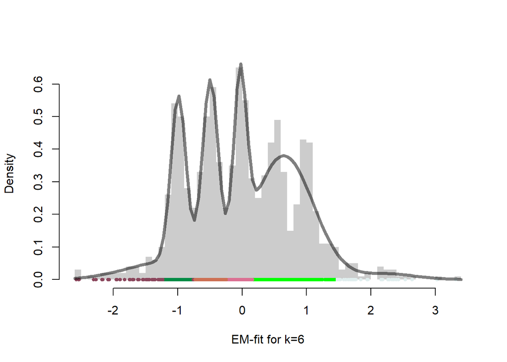

```r
#plotting function
plot_fit <- function(y, p, mu, sigma, xlab = "EM-fit for k=6", breaks = 50) {
  # sampling plot colors
  color_list <- grDevices::colors()[grep('gr(a|e)y', grDevices::colors(), invert = T)]
  k    <- length(p)
  cols <- sample(color_list, k)

  hist(y, prob = T, breaks = breaks, col = gray(.8), border = NA,
       main = "", xlab = xlab)
  set.seed(123)
  # compute max component for each obs
  norms <- vect_norm(y, mu, sigma)
  cols_idxs <- apply(norms, 1, which.max)
  curve_fun <- function(x) sum(vect_wnorm(x, p, mu, sigma))

  points(jitter(y), rep(0,length(y)),
         pch = 19, cex = .6,
         col = cols[cols_idxs])
  curve(sapply(x, curve_fun),
        lwd = 4, col = rgb(0,0,0,.5), add = TRUE)
}


# generate a fit for k=7
XX <- sample_sim(1000)
params <- init_kmeans(XX, 6)
hm.fit <- handmade.em(XX, params$p, params$mu, params$sigma)
plot_fit(XX, hm.fit$p, hm.fit$mu, hm.fit$sigma)
```

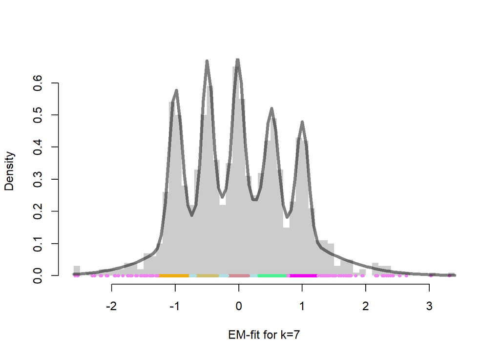

```r
# plot curve for k = 7
params <- init_kmeans(XX, 7)
hm.fit <- handmade.em(XX, params$p, params$mu, params$sigma)
plot_fit(XX, hm.fit$p, hm.fit$mu, hm.fit$sigma, xlab = "EM-fit for k=7")
```

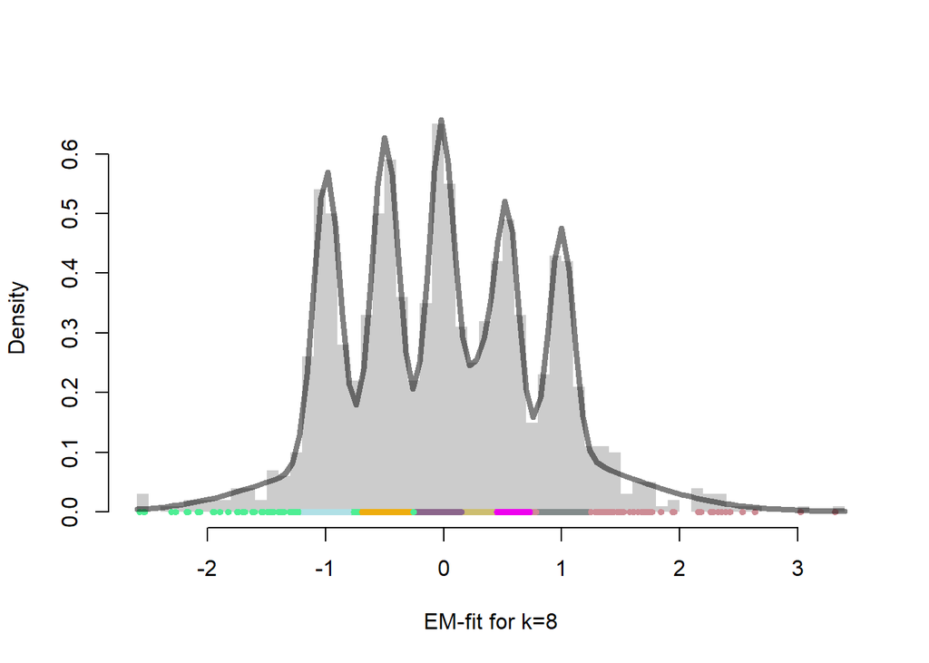

```r
#plot curve for k = 8
params <- init_kmeans(XX, 8)
hm.fit <- handmade.em(XX, params$p, params$mu, params$sigma)
plot_fit(XX, hm.fit$p, hm.fit$mu, hm.fit$sigma, xlab = "EM-fit for k=8")
```